# R Notebook

### VAR MODEL

Using weekly average close and weekly average sales.

```r
# bind variables together
X = cbind(mult_df_train$avgSales, mult_df_train$avgClose)
colnames(X) = c('Sales','Close')

X = na.omit(X)

# fit model
VAR_SM = VAR(X,lag.max = 17, type = 'both')

# predictions shor term
predsST = predict(VAR_SM,n.ahead = 5)
```

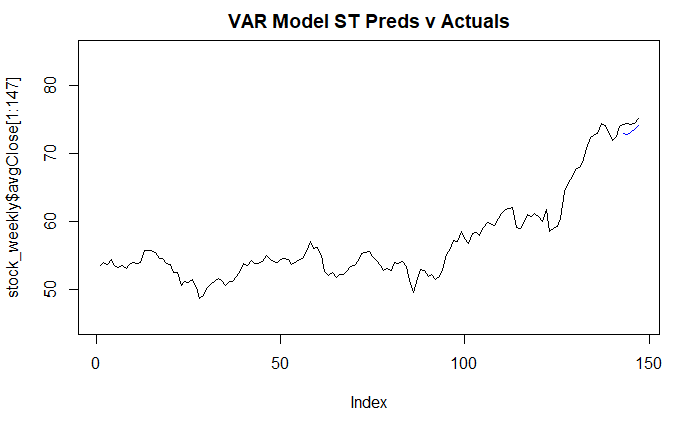

```r
# # plot forecast preds against actuals
plot(stock_weekly$avgClose[1:147], type='l',main = 'VAR Model ST Preds v Actuals',
      ylim = c(45,85))
lines(seq(143,147), predsST$fcst$Close[,1], col = 'blue')
```

How does our model do predicting the short term?

```r
# preds$fcst$Sales ## useful reference - keep in
ase_varST = mean((predsST$fcst$Close[1:5] - mult_df_test$avgClose[1:5])^2)
ase_varST
```

```
[1] 1.313919
```

```r
# rmse_varST = sqrt(ase_varST)
# rmse_varST
print(paste0('The ASE for the VAR model, short term is: ', round(ase_varST,4) ))
```

```
[1] "The ASE for the VAR model, short term is: 1.3139"
```

```r
print(paste0('The square root of the ASE for the VAR model, short term is: ', round(sqrt(ase_varST),4) ))
```

```
[1] "The square root of the ASE for the VAR model, short term is: 1.1463"
```

Long term predictions for VAR model.

```r
# predictions long term
preds = predict(VAR_SM,n.ahead = 15)
```

How does our model do predicting the long term?

```r
# preds$fcst$Sales ## useful reference - keep in
# predictions long term
preds = predict(VAR_SM,n.ahead = 15)
ase_var = mean((preds$fcst$Close[1:15] - mult_df_test$avgClose[1:15])^2)
ase_var
```

```
[1] 8.404515
```

```r
# rmse_var = sqrt(ase_var)
# rmse_var
print(paste0('The ASE for the VAR model, long term is: ', round(ase_var,4) ))
```

```
[1] "The ASE for the VAR model, long term is: 8.4045"
```

```r
print(paste0('The square root of the ASE for the VAR model, long term is: ', round(sqrt(ase_var),4) ))
```

```
[1] "The square root of the ASE for the VAR model, long term is: 2.8991"
```

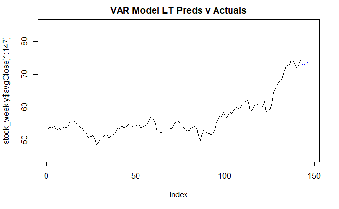

```r
# # plot forecast preds against actuals
plot(stock_weekly$avgClose[1:147], type='l',main = 'VAR Model LT Preds v Actuals',
      ylim = c(45,85))
lines(seq(143,147), predsST$fcst$Close[,1], col = 'blue')
```

MLP MODEL

```r
trainDF = data.frame(FISCAL_WEEK_END = ts(mult_df_train$FISCAL_WEEK_END),
                     avgOpen = ts(mult_df_train$avgOpen),
                     avgHigh = ts(mult_df_train$avgHigh),
                     avgLow = ts(mult_df_train$avgLow),
                     avgVolume = ts(mult_df_train$avgVolume),
                     avgSales = ts(mult_df_train$avgSales),
                     avgTemp = ts(mult_df_train$avgTemp))
                     # avgFuel = ts(mult_df_train$avgFuel))
                     # avgCPI = ts(mult_df_train$avgCPI),
                     # avgUnemp = ts(mult_df_train$avgUnemp))

fit.mlp = mlp(ts(mult_df_train$avgClose), reps = 20, comb = 'mean', xreg=trainDF)
fit.mlp
```

```
MLP fit with 5 hidden nodes and 20 repetitions.
Univariate lags: (2,3)
6 regressors included.
- Regressor 1 lags: (1,3)
- Regressor 2 lags: (1,2)
- Regressor 3 lags: (1,3)
- Regressor 4 lags: (2,3)
- Regressor 5 lags: (4)
- Regressor 6 lags: (3)
Forecast combined using the mean operator.
MSE: 0.6029.
```

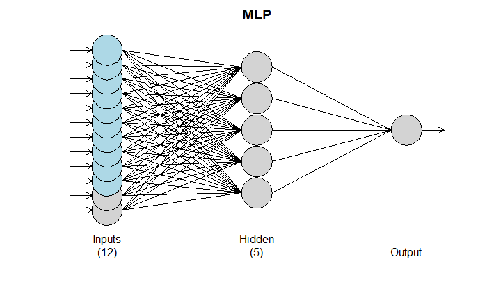

```r
plot(fit.mlp)
```

# MLP short term

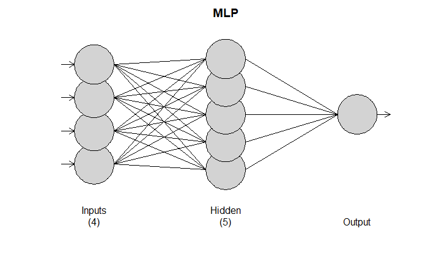

```r
set.seed(17)
#  Sales
fit.mlp.sales = mlp(ts(mult_df_train$avgSales, frequency = 5), reps= 20, comb = "median")
plot(fit.mlp.sales)
```

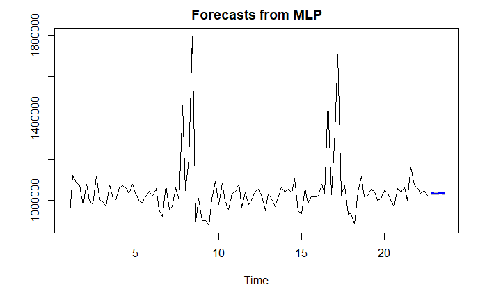

```r
fore.mlp.sales = forecast(fit.mlp.sales, h=5)
plot(fore.mlp.sales)
```

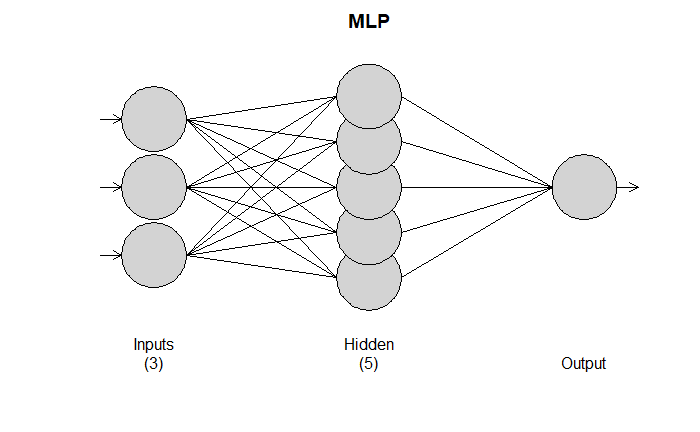

```r
# temp
fit.mlp.temp = mlp(ts(mult_df_train$avgTemp, frequency = 5), reps= 20, comb = "median")
plot(fit.mlp.temp)
```

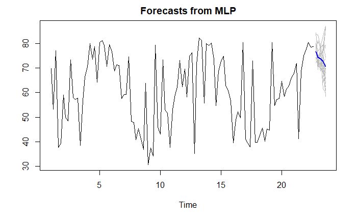

```r
fore.mlp.temp = forecast(fit.mlp.temp, h=5)
plot(fore.mlp.temp)
```

```r
df_fore = data.frame(week = ts(seq(1,114,1)),
                     temp = ts(c(mult_df_train$avgTemp, fore.mlp.temp$mean)),
                     sales = ts(c(mult_df_train$avgSales, fore.mlp.sales$mean)))
df_fore
```

| week | temp | sales |
| --- | --- | --- |
| 1 | 69.86800 | 938663.9 |
| 2 | 53.12089 | 1120529.6 |
| 3 | 77.13333 | 1087055.2 |
| 4 | 37.71978 | 1072822.1 |
| 5 | 39.24356 | 977079.4 |
| 6 | 59.01656 | 1078925.4 |
| 7 | 49.95422 | 999755.0 |
| 8 | 48.47356 | 980754.7 |
| 9 | 73.41089 | 1115301.0 |
| 10 | 58.02111 | 1004081.5 |

[output cut: 104 more lines]

```r
multdf = data.frame(week = ts(mult_df_train$FISCAL_WEEK_END),
                    temp = ts(mult_df_train$avgTemp),
                    sales = ts(mult_df_train$avgSales))

fit.mlp = mlp(ts(mult_df_train$avgClose, frequency = 5), reps=20, comb = 'mean', xreg = multdf)
fit.mlp
```

```
MLP fit with 5 hidden nodes and 20 repetitions.
Series modelled in differences: D1.
Univariate lags: (3)
3 regressors included.
- Regressor 1 lags: (2)
- Regressor 2 lags: (3)
- Regressor 3 lags: (4,5)
Forecast combined using the mean operator.
MSE: 0.3763.
```

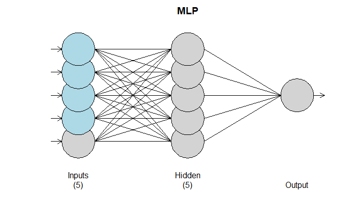

```r
plot(fit.mlp)
```

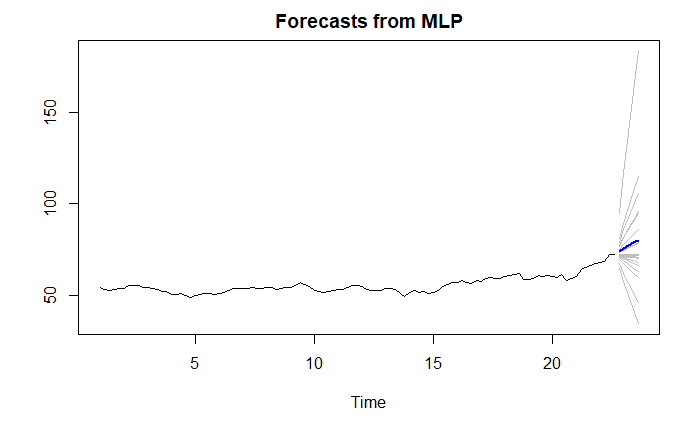

```r
fore.mlp = forecast(fit.mlp, h=5, xreg = df_fore)
plot(fore.mlp)
```

```r
ASE = mean((mult_df_test$avgClose[1:5] - fore.mlp$mean)^2)
ASE
```

```
[1] 25.67212
```

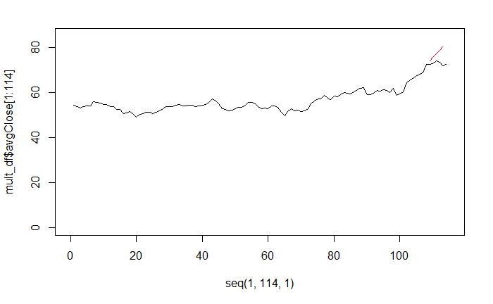

```r
set.seed(17)
plot(seq(1,114,1), mult_df$avgClose[1:114], type='l', xlim = c(0,115), ylim = c(0,85))
lines(seq(109,113,1), fore.mlp$mean, type='l', col = 'red')
```

```r
roll_mlp01ST = roll.win.rmse.wge(stock_train$avgClose, horizon = 5, phi = mod01est$phi,
                                  theta = mod01est$theta)
```

```
[1] "Please Hold For a Moment, TSWGE is processing the Rolling Window RMSE with 136 windows."
[1] "The Summary Statistics for the Rolling Window RMSE Are:"
   Min. 1st Qu.  Median    Mean 3rd Qu.    Max.
 0.2595  0.9216  1.4576  1.6446  2.0328  6.2197
[1] "The Rolling Window RMSE is:  1.645"
```

```r
roll_mlp01ST_rmse = round(roll_mlp01ST$rwRMSE,4)
print(paste0('The rolling window RMSE for our MLP model, short term is: ', roll_mlp01ST_rmse))
```

```
[1] "The rolling window RMSE for our MLP model, short term is: 1.6446"
```

# MLP long term

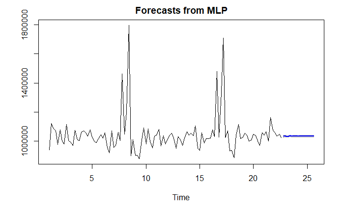

```r
set.seed(17)
#  Sales
# fit.mlp.sales = mlp(ts(mult_df_train$avgSales, frequency = 15), reps= 20, comb = "median")
# plot(fit.mlp.sales)

# use fit from above
fore.mlp.sales = forecast(fit.mlp.sales, h=15)
plot(fore.mlp.sales)
```

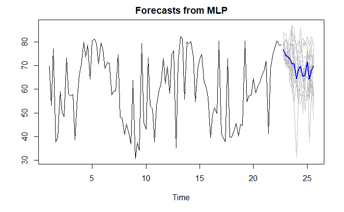

```r
# temp
# fit.mlp.temp = mlp(ts(mult_df_train$avgTemp, frequency = 15), reps= 20, comb = "median")
# plot(fit.mlp.temp)

# use fit from above
fore.mlp.temp = forecast(fit.mlp.temp, h=15)
plot(fore.mlp.temp)
```

```r
df_foreLT = data.frame(week = ts(seq(1,124,1)),
                     temp = ts(c(mult_df_train$avgTemp, fore.mlp.temp$mean)),
                     sales = ts(c(mult_df_train$avgSales, fore.mlp.sales$mean)))
df_foreLT
```

| week | temp | sales |
| --- | --- | --- |
| 1 | 69.86800 | 938663.9 |
| 2 | 53.12089 | 1120529.6 |
| 3 | 77.13333 | 1087055.2 |
| 4 | 37.71978 | 1072822.1 |
| 5 | 39.24356 | 977079.4 |
| 6 | 59.01656 | 1078925.4 |
| 7 | 49.95422 | 999755.0 |
| 8 | 48.47356 | 980754.7 |
| 9 | 73.41089 | 1115301.0 |
| 10 | 58.02111 | 1004081.5 |

[output cut: 114 more lines]

```r
multdfLT = data.frame(week = ts(mult_df_train$FISCAL_WEEK_END),
                    temp = ts(mult_df_train$avgTemp),
                    sales = ts(mult_df_train$avgSales))

fit.mlpLT = mlp(ts(mult_df_train$avgClose, frequency = 15), reps=20, comb = 'mean', xreg = multdfLT)
fit.mlpLT
```

```
MLP fit with 5 hidden nodes and 20 repetitions.
Series modelled in differences: D1.
Univariate lags: (5,6,12,15)
3 regressors included.
- Regressor 1 lags: (1,3,4,6,10,11,12,14)
- Regressor 2 lags: (2,6,8,9,10,13,15)
- Regressor 3 lags: (3,5,8,9,11,12,13,14)
Forecast combined using the mean operator.
MSE: 0.0054.
```

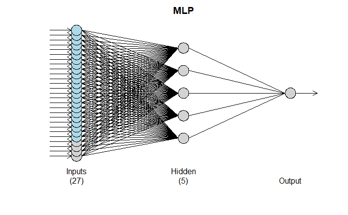

```r
plot(fit.mlpLT)
```

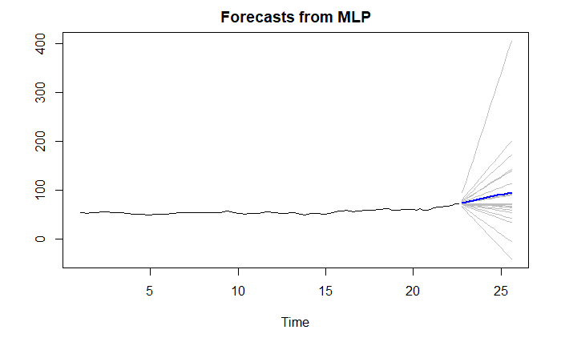

```r
fore.mlpLT = forecast(fit.mlp, h=15, xreg = df_foreLT)
plot(fore.mlpLT)
```

```r
ASE_LT = mean((mult_df_test$avgClose[1:15] - fore.mlpLT$mean)^2)
ASE_LT
```

```
[1] 170.1357
```

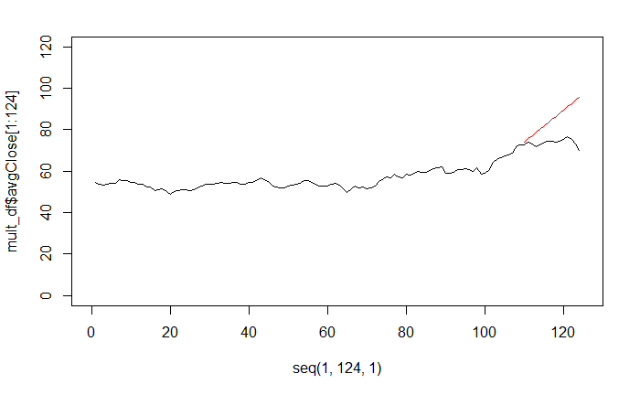

```r
set.seed(17)
plot(seq(1,124,1), mult_df$avgClose[1:124], type='l', xlim = c(0,125), ylim = c(0,120))
lines(seq(110,124,1), fore.mlpLT$mean, type='l', col = 'red')
```

```r
roll_mlp01LT = roll.win.rmse.wge(stock_train$avgClose, horizon = 5, phi = mod01est$phi,
                                  theta = mod01est$theta)
```

```
[1] "Please Hold For a Moment, TSWGE is processing the Rolling Window RMSE with 136 windows."
[1] "The Summary Statistics for the Rolling Window RMSE Are:"
   Min. 1st Qu.  Median    Mean 3rd Qu.    Max.
 0.2595  0.9216  1.4576  1.6446  2.0328  6.2197
[1] "The Rolling Window RMSE is:  1.645"
```

```r
roll_mlp01LT_rmse = round(roll_mlp01LT$rwRMSE,4)
print(paste0('The rolling window RMSE for our MLP model, long term is: ', roll_mlp01LT_rmse))
```

[output not shown]

# emsemble short term

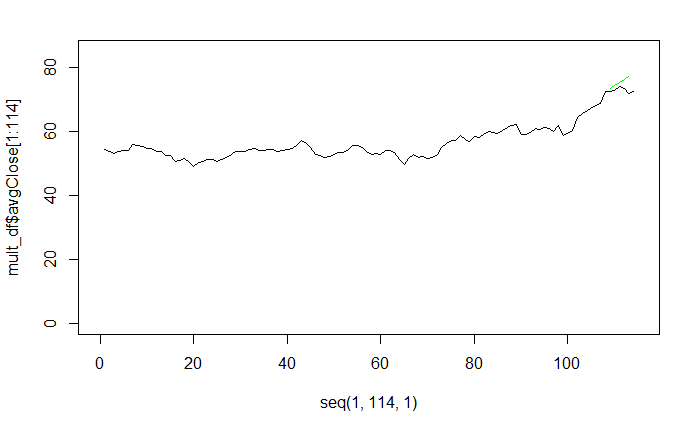

```r
set.seed(17)
ensemble = (predsST$fcst$Close[,1] + fore.mlp$mean)/2
plot(seq(1,114,1), mult_df$avgClose[1:114], type='l', xlim = c(0,115), ylim = c(0,85))
lines(seq(109,113,1), ensemble, type='l', col = 'green')
```

```r
ASE_ensST = mean((mult_df_test$avgClose[1:5] - ensemble)^2)
ASE_ensST
```

```
[1] 8.790605
```

```r
print(paste0('The ASE for the Ensemble model, short term is: ', round(ASE_ensST,4) ))
```

```
[1] "The ASE for the Ensemble model, short term is: 8.7906"
```

# emsemble long term

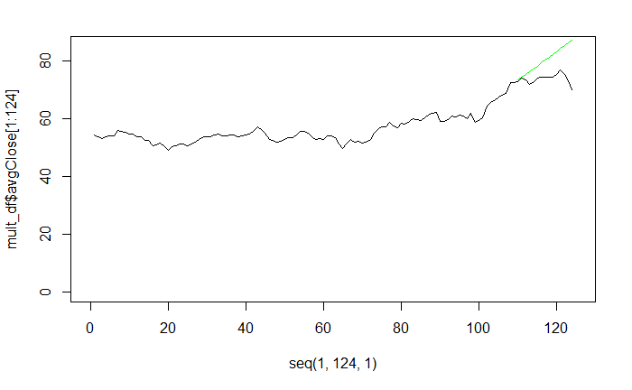

```r
set.seed(17)
ensembleLT = (preds$fcst$Close[,1] + fore.mlpLT$mean)/2
plot(seq(1,124,1), mult_df$avgClose[1:124], type='l', xlim = c(0,125), ylim = c(0,85))
lines(seq(110,124,1), ensembleLT, type='l', col = 'green')
```

```r
ASE_ensLT = mean((mult_df_test$avgClose[1:15] - ensembleLT)^2)
ASE_ensLT
```

```
[1] 61.19943
```

```r
print(paste0('The ASE for the Ensemble model, long term is: ', round(ASE_ensLT,4) ))
```

```
[1] "The ASE for the Ensemble model, long term is: 61.1994"
```

FINAL CONCLUSION

RMSE Comparison of forecasts (on stock data, univariate & multivariate analysis).

```r
print(paste0('The rolling window RMSE for Model 01. AR(1), short term is: ', roll_mod01ST_rmse))
```

```
[1] "The rolling window RMSE for Model 01. AR(1), short term is: 1.6446"
```

```r
print(paste0('The rolling window RMSE for Model 01. AR(1), long term is: ', roll_mod01LT_rmse))
```

[output not shown]

```r
print(paste0('The rolling window RMSE for Model 02. ARIMA(1,2,1), short term is: ', roll_mod02ST_rmse))
```

```
[1] "The rolling window RMSE for Model 02. ARIMA(1,2,1), short term is: 4.3337"
```

```r
print(paste0('The rolling window RMSE for Model 02. ARIMA(1,2,1), long term is: ', roll_mod01LT_rmse))
```

[output not shown]

```r
print(paste0('The rolling window RMSE for our MLP model, short term is: ', roll_mlp01ST_rmse))
```

[output not shown]

```r
print(paste0('The rolling window RMSE for our MLP model, long term is: ', roll_mlp01LT_rmse))
```

[output not shown]

ASE Short term / Long term for VAR Model & Ensemble Model

```r
print(paste0('The ASE for the VAR model, short term is: ', round(ase_varST,4) ))
```

```
[1] "The ASE for the VAR model, short term is: 1.3139"
```

```r
print(paste0('The square root of the ASE for the VAR model, short term is: ', round(sqrt(ase_varST),4) ))
```

```
[1] "The square root of the ASE for the VAR model, short term is: 1.1463"
```

```r
print(paste0('The ASE for the VAR model, long term is: ', round(ase_var,4) ))
```

```
[1] "The ASE for the VAR model, long term is: 8.4045"
```

```r
print(paste0('The square root of the ASE for the VAR model, long term is: ', round(sqrt(ase_var),4) ))
```

```
[1] "The square root of the ASE for the VAR model, long term is: 2.8991"
```

```r
print(paste0('The ASE for the Ensemble model, short term is: ', round(ASE_ensST,4) ))
```

```
[1] "The ASE for the Ensemble model, short term is: 8.7906"
```

```r
print(paste0('The square root of the ASE for the Ensemble model, short term is: ', round(sqrt(ASE_ensST),4) ))
```

```
[1] "The square root of the ASE for the Ensemble model, short term is: 2.9649"
```

```r
print(paste0('The ASE for the Ensemble model, long term is: ', round(ASE_ensLT,4) ))
```

```
[1] "The ASE for the Ensemble model, long term is: 61.1994"
```

```r
print(paste0('The square root of the ASE for the Ensemble model, long term is: ', round(sqrt(ASE_ensLT),4) ))
```

```
[1] "The square root of the ASE for the Ensemble model, long term is: 7.823"
```

### IDEAS FOR FUTURE ANALYSIS

Model 001. ARIMA(2,2,2)

Difference the data again.

```r
# # pass in the differenced data
# mod02df1 = artrans.wge(mod02df, 1)
# plotts.sample.wge(mod02df1,arlimit=TRUE)
# aic5.wge(mod02df1)
```

```r
# mod02est = est.arma.wge(mod02df4,p=1, q = 1)
#
# mean(mod02df1)
# mod02est$phi
# mod02est$theta
# mod02est$avar
```

Model 002. With moving average filter Applying a moving average filter might be useful, as well.

```r
# # moving average filter (low-pass filter)
# library(forecast)
# ma_train01 = ma(stock_train$avgClose, order = 2)
```

Model 003. Multiple regression with correlated errors.

When the dependent and independent variables depend on time, it is common for the errors (residuals) to be auto-correlated.

Process Overview (MLE Approach)

Step 1. Regression analysis and model residuals. Step 1a. Fit regression model. Step 1b. Model ID on residuals.

Step 2. Use function ARIMA to perform MLE analysis which estimates the coefficient in the multiple regression while simultaneously modeling Z(t) as an AR(phi$p).

Use our new dataframe to model the data.

```r
# # Step 1a. Regression analysis.
#
# # response = avgClose price
# # explain variables = avgSales, avgFuel, avgCPI, avgUnemp
#
# ksfit = lm(mult_df_train$avgClose ~ mult_df_train$avgSales + mult_df_train$avgFuel + mult_df_train$avgCPI + mult_df_train$avgUnemp)
#
# # plot residuals
# # plot(ksfit$residuals, type='l')
# plotts.wge(ksfit$residuals)
#
# # acf on residuals
# acf(ksfit$residuals)
# # residuals look in line with stationary behavior
#
# parzen.wge(ksfit$residuals)
```

```r
# # model id on the residuals
# suppressWarnings(aic.wge(ksfit$residuals, p=0:17))
# # AIC picks p = 12, q = 2
```

```r
# AIC picks AR(1)

# next, store the parameter estimates in objects
# ksfit_params = suppressWarnings(aic.wge(ksfit$residuals, p=0:17))
```

```r
# fit ARIMA model using lagged variables with correlation ARMA(12,2)
# response = avgClose price
# explain variables = avgSales, avgFuel, avgCPI, avgUnemp
```